# 언어심리학을 위한 데이터 사이언스 11주차: 데이터 사이언스 #3-4 (데이터 분석)

## (6) 반복측정 설계(repeated measures designs): 일원/이원 반복측정 분산분석(one-/two-way repeated measures designs)

- 데이터셋 개관(`sniff_tib`)
  - 외계인 판별 훈련을 받은 여덟 마리의 개가 1분 동안 외계인(외형: 파충류 vs. 인간), 인간, 마네킨의 냄새를 맡고 정체를 구분할 수 있는지 여부를 알아보는 실험으로부터 수집한 자료.
  - 독립변수(`entity`): 인간 형상 외계인/파충류 형상 외계인/인간/마네킨 여부.
  - 조건/집단
    - 마네킨.
    - 인간 집단.
    - 인간 형상 외계인 집단.
    - 파충류 형상 외계인 집단.
  - 종속변수(`vocalisations`): 1분 간 냄새를 맡고 짖는 횟수.
- 연구가설: 외계인 판별 훈련을 성공적으로 완수한 개는 비외계인보다 외계인의 체취에 더 강하게 반응하며 많이 짖을 것이다.

### A. 모형 수립하기

- 모형 개관
  - 예측변수: 여러 개의 더미 변수가 아닌 한 개의 예측변수 `entity`(실제 정체)를 예측변수로 사용.
  - 절편 $\hat{b}_{0j}$: 전반적 절편 $\hat{b}_{0}$과 각각의 개에 대한 절편의 분산 추정치 $\hat{u}_{0j}$로 구성. 즉 각각의 개는 기본적으로 짖는 횟수에 개인차가 있다는 사실을 모형에 반영. 원래 짖음이 헤픈 개가 있고, 원래 잘 안 짖는 개가 있을 수 있다는 것!
  - `entity`의 효과 $\hat{b}_{1j}$: 개마다 `entity`의 효과가 얼마나 다르게 나타나는지에 대한 추정치로 구성. 즉 각각의 개는 네 가지 존재의 체취를 판별하는 능력에 기본적으로 개인차가 있다는 사실을 모형에 반영.

$$\hat{vocalisations}_{ij} =
\hat{b}_{0j}+\hat{b}_{1j}entity_{ij}+e_{ij}$$
$$\hat{b}_{0j}=\hat{b}_{0}+\hat{u}_{0j}$$
$$\hat{b}_{1j}=\hat{b}_{1}+\hat{u}_{1j}$$

### B. 데이터 탐색하기

- 데이터 시각화

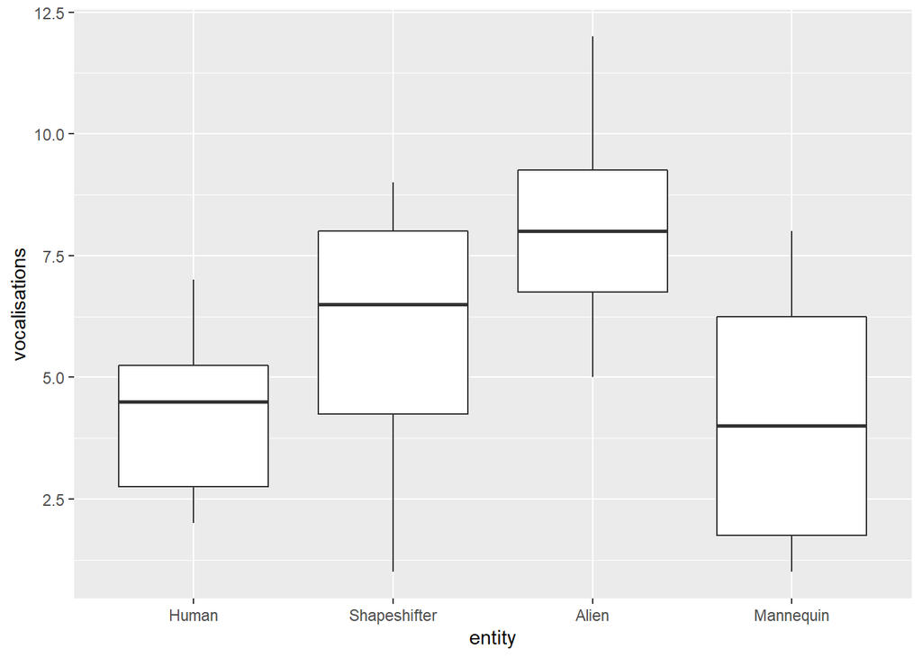

```r
load("sniff_tib.rda")

# 문자변수를 요인변수로 바꾸기.
sniff_tib.1 <- sniff_tib %>%
  mutate(entity = as_factor(entity) %>% fct_relevel("Human", "Shapeshifter", "Alien"))

# 상자 그래프 그리기.
sniff_tib.1 %>%
  ggplot(aes(x = entity, y = vocalisations)) + # 범주변수는 정체의 유형, 관찰값은 1분 간 짖은 횟수.
  geom_boxplot()
```

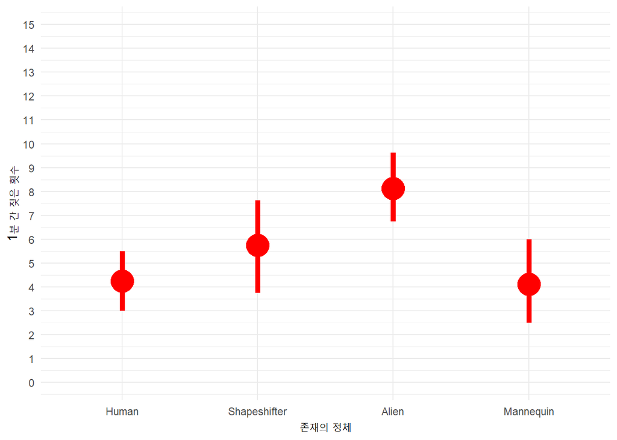

```r
# 집단 간 95퍼센트 신뢰구간 비교하기(신뢰구간이 겹치는지 확인).
sniff_tib.1 %>%
  ggplot(aes(x = entity, y = vocalisations)) +
  stat_summary(fun.data = "mean_cl_boot", colour = "red", lwd = 2) +
  coord_cartesian(ylim = c(0, 15)) +
  scale_y_continuous(breaks = seq(0, 15, 1)) +
  xlab("존재의 정체") +
  ylab("1분 간 짖은 횟수") +
  theme_minimal()
```

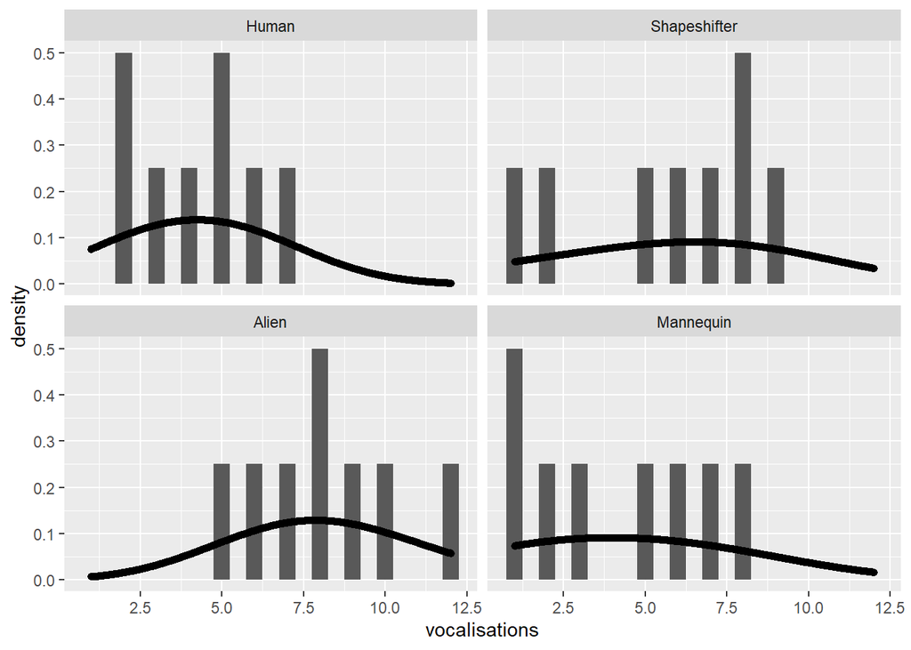

```r
# 히스토그램 그리기.
sniff_tib.1 %>%
  ggplot(aes(vocalisations)) +
  geom_histogram(aes(y = ..density..), binwidth = 0.5) +
  geom_density(adjust = 2, lwd = 2) +
  facet_wrap(~ entity)
```

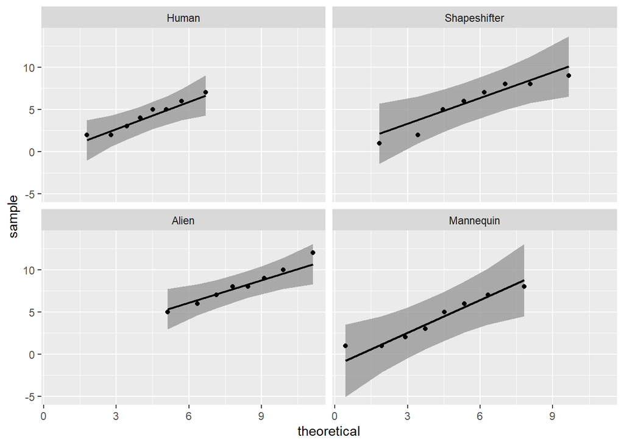

```r
# QQ-플롯 그리기.
library(qqplotr)
sniff_tib.1 %>%
  ggplot(aes(sample = vocalisations)) +
  stat_qq_band() +
  stat_qq_line() +
  stat_qq_point() +
  facet_wrap(~ entity)
```

- 기술통계량 분석

```r
# 기술통계량 구하기: tidyverse를 이용하는 경우.
sniff_tib.1 %>%
  group_by(entity) %>%
  summarise(
    n = n(),
    mean = mean(vocalisations),
    ci_lower = mean_cl_normal(vocalisations)$ymin,
    ci_upper = mean_cl_normal(vocalisations)$ymax)
```

```
## # A tibble: 4 x 5
##   entity           n  mean ci_lower ci_upper
##   <fct>        <int> <dbl>    <dbl>    <dbl>
## 1 Human            8  4.25     2.72     5.78
## 2 Shapeshifter     8  5.75     3.31     8.19
## 3 Alien            8  8.12     6.26     9.99
## 4 Mannequin        8  4.12     1.83     6.42
```

```r
# 기술통계량 구하기: psych를 이용하는 경우.
describeBy(sniff_tib.1, sniff_tib$entity)
```

```
##
##  Descriptive statistics by group
## group: Alien
##               vars n mean   sd median trimmed  mad min max range skew kurtosis
## dog_name*        1 8 4.50 2.45    4.5    4.50 2.97   1   8     7 0.00    -1.65
## entity*          2 8 3.00 0.00    3.0    3.00 0.00   3   3     0  NaN      NaN
## vocalisations    3 8 8.12 2.23    8.0    8.12 2.22   5  12     7 0.27    -1.21
##                 se
## dog_name*     0.87
## entity*       0.00
## vocalisations 0.79
## ------------------------------------------------------------
## group: Human
##               vars n mean   sd median trimmed  mad min max range skew kurtosis
## dog_name*        1 8 4.50 2.45    4.5    4.50 2.97   1   8     7 0.00    -1.65
## entity*          2 8 1.00 0.00    1.0    1.00 0.00   1   1     0  NaN      NaN
## vocalisations    3 8 4.25 1.83    4.5    4.25 2.22   2   7     5 0.05    -1.66
##                 se
## dog_name*     0.87
## entity*       0.00
## vocalisations 0.65
## ------------------------------------------------------------
## group: Mannequin
##               vars n mean   sd median trimmed  mad min max range skew kurtosis
## dog_name*        1 8 4.50 2.45    4.5    4.50 2.97   1   8     7  0.0    -1.65
## entity*          2 8 4.00 0.00    4.0    4.00 0.00   4   4     0  NaN      NaN
## vocalisations    3 8 4.12 2.75    4.0    4.12 3.71   1   8     7  0.1    -1.86
##                 se
## dog_name*     0.87
## entity*       0.00
## vocalisations 0.97
## ------------------------------------------------------------
## group: Shapeshifter
##               vars n mean   sd median trimmed  mad min max range  skew kurtosis
## dog_name*        1 8 4.50 2.45    4.5    4.50 2.97   1   8     7  0.00    -1.65
## entity*          2 8 2.00 0.00    2.0    2.00 0.00   2   2     0   NaN      NaN
## vocalisations    3 8 5.75 2.92    6.5    5.75 2.22   1   9     8 -0.51    -1.49
##                 se
## dog_name*     0.87
## entity*       0.00
## vocalisations 1.03
```

### C. 모형 적합도 분석하기

#### 1) 반복측정 모형 적합도 분석하기

- **afex** 패키지의 `aov_4` 함수 사용
  - (반복측정 예측변수|참여자_변수) 논항: 데이터의 구조에 대한 정보. 개별 참여자(외계인 감별 훈련을 받은 개)가 네 가지 존재의 정체에 대해 반복적으로 평정(냄새 맡고 짖기)을 시행했음을 가리킴.
  - 변수: 예측변수 효과 검증.

> aov_4(종속변수 ~ 독립변수 + (반복측정 예측변수|참여자_변수), data = 데이터프레임)

```r
library(afex)
sniff_afex <- aov_4(vocalisations ~ entity + (entity|dog_name), data = sniff_tib.1)
```

#### 2) **emmeans** 패키지의 `emmeans` 함수를 사용한 평균 계산

- estimated marginal means 분석
  - 만약 `entity`의 효과가 통계적으롱 유의미했다면, 과연 어떤 조건 간 차이로 인해 그런 결과가 발생했는지 알고 싶을 것.
  - **emmeans** 패키지의 `emmeans` 함수: 예측변수 `entity` 조건별 평균을 얻고, 이들 평균을 비교한 사후검정을 실시하는 데 사용. 그렇게 얻은 estimated marginal means는 대조분석 또는 사후검정에 사용 가능.
  - `model` 논항: `model` = “multivariate”은 **구형성을 가정하지 않는** 검정 통계량을 사용하여 대조분석이 실시됨을 의미.
  - 결과해석: 파충류 외계인이나 인간 형상의 외계인의 냄새를 맡을 때 가장 많이 짖었으며, 인간과 마네킨의 냄새를 맡을 때는 상대적으로 덜 짖었음을 알 수 있음. 이렇게 얻은 평균 `sniff_emm`은 대조분석에 투입 가능.

```r
# emmeans 패키지의 emmeans 함수를 사용하여 평균 계산하기.
sniff_emm <- emmeans(sniff_afex, ~entity, model = "multivariate")
```

#### 3) 독립적 대조 설정하기

- 대조 계획하기
  - 대조 1: {alien, shapeshifter} vs. {human, mannequin}
  - 대조 2: {alien} vs. {shapeshifter}
  - 대조 3: {human} vs. {mannequin}
- 대조 코딩의 규칙
  1. 대조의 개수는 $k-1$($k$는 독립변수 층위의 개수)개의 대조를 생성하라. 집단의 수가 4개이므로, 대조는 3개를 설정.
  2. 한 chunk({ } 묶음)에는 + 가중치, 다른 chunk에는 - 가중치를 부여함.
  3. 최초의 가중치: 반대 chunk 내 집단의 수(대조 1의 경우, chunk 1 = 2개, chunk 2 = 2개)에 해당하는 수.
  4. 마지막 가중치: 최초의 가중치(대조 1의 경우, chunk 1 = 2개 + chunk 2 = 2개)를 0이 아닌 가중치를 가진 chunk 내 집단의 수(대조 1의 경우, 2 + 2 = 총 4개)로 나눈 수(대조 1의 경우, alien = 1/2, human = -1/2, mannequin = -1/2, shapeshifter = 1/2)

| 집단 | 대조 1 (외계인 vs. 비외계인) | 대조 2 (파충류 외계인 vs. 인간 형상 외계인) | 대조 3 (인간 vs. 마네킨) |
| --- | --- | --- | --- |
| 파충류 외계인 | 1/2 | 1/2 | 0 |
| 인간 | -1/2 | 0 | 1/2 |
| 마네킨 | -1/2 | 0 | -1/2 |
| 인간형상 외계인 | 1/2 | -1/2 | 0 |

- **emmmeans** 패키지의 `contrast` 함수를 사용한 대조 시행
  1. 대조 설정하기: 리스트 객체로 만들어주는 R의 내장함수인 `list`를 사용하여 사전대조들을 리스트화하기.
  2. 대조 시행하기: `contrast` 함수에 `emmeans` 함수로 계산한 평균과 대조 리스트 투입하기.
  3. 사후검정 시행하기: `emmeans` 함수에 `list(pairwise ~ 예측변수)` 논항을 투입하기.
  4. 결과해석: 외계인 탐지 훈련을 받은 개는 인간이나 마네킨보다 외계인을 더 잘 판별해내는 것으로 나타남.

> contrast(emmeans 함수로 생성한 emmeans 객체, 대조 리스트, adjust = “holm”)

```r
# 대조 리스트 생성하기.
sniff_cons <- list(
  aliens_vs_non = c(1/2, -1/2, -1/2, 1/2),
  alien_vs_shape = c(1/2, 0, 0, -1/2),
  human_vs_manquin = c(0, 1/2, -1/2, 0)
  )

# emmeans의 contrast 함수를 사용하여 사전계획된 대조 리스트에 대한 대조 시행하기.
contrast(sniff_emm, sniff_cons)
```

```
##  contrast         estimate    SE df t.ratio p.value
##  aliens_vs_non     -2.7500 0.641  7  -4.291  0.0036
##  alien_vs_shape     0.0625 0.601  7   0.104  0.9201
##  human_vs_manquin  -1.1875 0.896  7  -1.325  0.2267
```

```r
# emmeans 패키지의 emmeans 함수로 사후검정 시행하기.
emmeans(sniff_afex, list(pairwise ~ entity), adjust = "bonferroni")
```

```
## $`emmeans of entity`
##  entity       emmean    SE df lower.CL upper.CL
##  Human          4.25 0.648  7     2.72     5.78
##  Shapeshifter   5.75 1.031  7     3.31     8.19
##  Alien          8.12 0.789  7     6.26     9.99
##  Mannequin      4.12 0.972  7     1.83     6.42
##
## Confidence level used: 0.95
##
## $`pairwise differences of entity`
##  1                        estimate    SE df t.ratio p.value
##  Human - Shapeshifter       -1.500 1.336  7  -1.122  1.0000
##  Human - Alien              -3.875 0.811  7  -4.775  0.0121
##  Human - Mannequin           0.125 1.202  7   0.104  1.0000
##  Shapeshifter - Alien       -2.375 1.792  7  -1.325  1.0000
##  Shapeshifter - Mannequin    1.625 1.822  7   0.892  1.0000
##  Alien - Mannequin           4.000 0.732  7   5.465  0.0056
##
## P value adjustment: bonferroni method for 6 tests
```

```r
# R의 내장함수인 pairs 함수로 사후검정 시행하기.
pairs(sniff_emm, adjust = "bon") # 위와 동일한 결과 도출.
```

```
##  contrast                 estimate    SE df t.ratio p.value
##  Human - Shapeshifter       -1.500 1.336  7  -1.122  1.0000
##  Human - Alien              -3.875 0.811  7  -4.775  0.0121
##  Human - Mannequin           0.125 1.202  7   0.104  1.0000
##  Shapeshifter - Alien       -2.375 1.792  7  -1.325  1.0000
##  Shapeshifter - Mannequin    1.625 1.822  7   0.892  1.0000
##  Alien - Mannequin           4.000 0.732  7   5.465  0.0056
##
## P value adjustment: bonferroni method for 6 tests
```

#### 4) 비모수 반복측정 분산분석

- `aov_4` 함수로 모형 적합도 분석 시 플롯을 사용한 모형의 진단이 불가능함.
- `WRS2` 패키지를 사용한 비모수 반복측정 분산분석
  - robust 기법을 사용하여 반복측정 설계로 세 개 이상의 평균을 비교할 수 있음.
  - `rmanova` 함수
    - 방법: 양극단의 20% 관찰값을 제거한 뒤 평균을 계산.
    - 논항
      - `y`: 결과변수 투입.
      - `groups`: 집단 내 변수 투입.
      - `blocks`: 참여자 ID 변수.
      - `tr = 0.2`: 양극단의 20% 관찰값 제거. 디폴트 값. 이보다 더 늘리거나 줄일 수 있음.
    - 결과: $F_t(2.31,11.55)=2.75,\text{ }p=0.10$.
  - `rmmcp` 함수: 사후검정 실행.
    - 결과
      - *p* 값 $<$ `p.crit`이면, 사후검정도 유의할 것이고, `sig` 열 또한 TRUE일 것.
      - *p* 값 $>$ `p.crit`이면, 사후검정은 유의하지 않을 것이고, `sig` 열 또한 FALSE일 것.

> rmanova(y = 결과변수, groups = 집단 내 예측변수, blocks = 참여자 ID, tr = 0.2)

> rmmcp(y = 결과변수, groups = 집단 내 예측변수, blocks = 참여자 ID, tr = 0.2)

```r
# rmanova 함수로 비모수 반복측정 분산분석 시행.
rmanova(y = sniff_tib.1$vocalisations,
        groups = sniff_tib.1$entity,
        blocks = sniff_tib.1$dog_name)
```

```
## Call:
## rmanova(y = sniff_tib.1$vocalisations, groups = sniff_tib.1$entity,
##     blocks = sniff_tib.1$dog_name)
##
## Test statistic: F = 2.7528
## Degrees of freedom 1: 2.31
## Degrees of freedom 2: 11.55
## p-value: 0.1002
```

```r
# rmmcp 함수로 비모수 반복측정 분산분석 사후검정 시행.
rmmcp(y = sniff_tib.1$vocalisations,
  groups = sniff_tib.1$entity,
  blocks = sniff_tib.1$dog_name)
```

```
## Call:
## rmmcp(y = sniff_tib.1$vocalisations, groups = sniff_tib.1$entity,
##     blocks = sniff_tib.1$dog_name)
##
##                              psihat  ci.lower ci.upper p.value  p.crit   sig
## Alien vs. Human             3.66667  -0.48300  7.81633 0.01360 0.01020 FALSE
## Alien vs. Mannequin         4.00000  -0.35728  8.35728 0.01172 0.00851 FALSE
## Alien vs. Shapeshifter      2.00000  -8.09920 12.09920 0.44148 0.01690 FALSE
## Human vs. Mannequin         0.00000  -5.38802  5.38802 1.00000 0.05000 FALSE
## Human vs. Shapeshifter     -1.83333  -9.23266  5.56599 0.34371 0.01270 FALSE
## Mannequin vs. Shapeshifter -2.00000 -12.54827  8.54827 0.46001 0.02500 FALSE
```

### D. 팩토리얼 설계 반복측정 분산분석

- 데이터셋 개관(`scents_tib`)
  - 외계인 판별 훈련을 받은 50마리의 개가 1분 동안 파충류 형상 외계인, 인간 형상 외계인, 인간 총 9개체의 냄새를 맡고 정체성을 구분할 수 있는지 여부를 알아보는 실험으로부터 수집한 자료.
  - 외계인과 인간의 경우, 개체당 인간 냄새, 여우 냄새, 무(無) 냄새를 한 번씩 덧칠하여 masking한 뒤, 훈련견이 반복 탐지함.
  - 집단 간 변수(`entity`): 개체의 유형
    - 인간 집단.
    - 인간 형상 외계인 집단.
    - 파충류 형상 외계인 집단.
  - 집단 내 변수(`scent_mask`): masking 냄새
    - 여우 냄새.
    - 인간 냄새.
    - 무(無) 냄새.
  - 종속변수(`vocalisations`): 1분 간 냄새를 맡고 짖는 횟수.
- 연구가설
  - 외계인 판별 훈련을 성공적으로 완수한 개는 비외계인보다 외계인의 체취에 더 강하게 반응하며 많이 짖을 것이다.
  - 외계인 판별 훈련을 성공적으로 완수한 개는 masking에도 불구하고 원래 개체의 냄새를 더 잘 탐지하여 더 많이 짖을 것이다.

#### 1) 모형 수립하기

- 모형 개관
  - 예측변수: 두 개의 독립변수 `entity`(실제 정체), `scent_mask`(masking한 냄새)를 예측변수로 사용.
  - 절편 $\hat{b}_{0j}$: 전반적 절편 $\hat{b}_{0}$과 각각의 개에 대한 절편의 분산 추정치 $\hat{u}_{0j}$로 구성. 즉 각각의 개는 기본적으로 짖는 횟수에 개인차가 있다는 사실을 모형에 반영. 원래 짖음이 헤픈 개가 있고, 원래 잘 안 짖는 개가 있을 수 있다는 것!
  - `entity`의 효과 $\hat{b}_{1j}$: 개마다 `entity`와 `scent_mask`의 효과가 얼마나 다르게 나타나는지에 대한 추정치로 구성. 즉 각각의 개는 세 가지 존재의 정체를 판별하는 능력에 기본적으로 개인차가 있다는 사실을 모형에 반영.
  - 가장 복잡한 형식의 모형
    - 모든 모수($b$)의 효과가 개별 참여자(훈련견)마다 다 차이가 있을 가능성을 포함.
    - 이는 모형에 큰 복잡성을 야기.

$$\hat{vocalisations}_{ij} =
\hat{b}_{0j}+\hat{b}_{1j}entity_{ij}+\hat{b}_{2j}scent\text{ }
mask_{ij}+\hat{b}_{3j}(entity_{ij}×scent_{ij})+e_{ij}$$
$$\hat{b}_{0j}=\hat{b}_{0}+\hat{u}_{0j}$$
$$\hat{b}_{1j}=\hat{b}_{1}+\hat{u}_{1j}$$
$$\hat{b}_{2j}=\hat{b}_{2}+\hat{u}_{2j}$$
$$\hat{b}_{3j}=\hat{b}_{3}+\hat{u}_{3j}$$

- 가장 단순한 버전의 모형
  - 예측변수의 효과를 고정된 것으로 취급.
  - 개별 참여자(훈련견)마다 기본적으로 짖음의 횟수에 차이가 있을 것으로 예상. 따라서 절편 모수 $\hat{b}_{0j}$를 모형에 포함시킴.

$$\hat{vocalisations}_i =
\hat{b}_{0j}+\hat{b}_1entity_{ij}+\hat{b}_2scent\text{ }
mask_{ij}+\hat{b}_3(entity_{ij}×scent\text{ }mask_{ij})+e_{ij}$$
$$\hat{b}_{0j}=\hat{b}_{0}+\hat{u}_{0j}$$

#### 2) 데이터 탐색하기

- 데이터 시각화

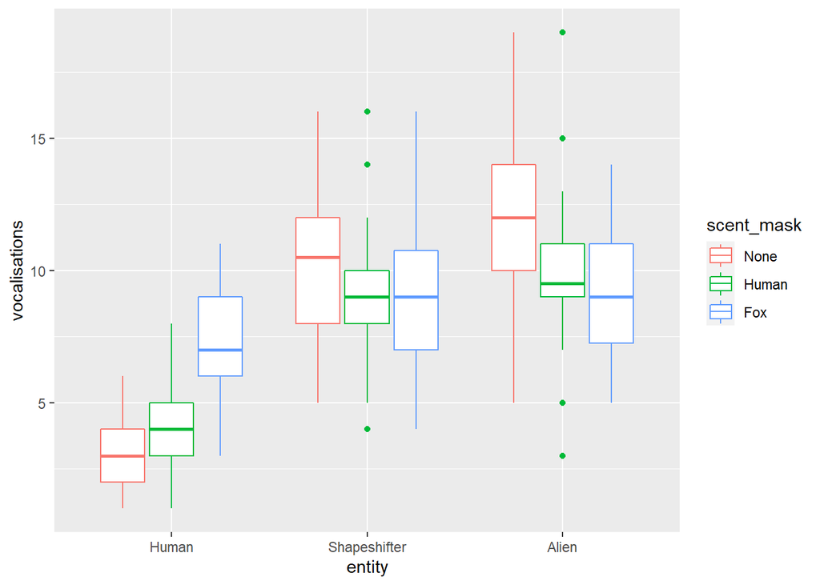

```r
load("scents_tib.rda")

# 문자변수를 요인변수로 바꾸기.
scents_tib.1 <- scents_tib %>%
  mutate(entity = as_factor(entity) %>% fct_relevel("Human", "Shapeshifter", "Alien"),
         scent_mask = as_factor(scent_mask) %>% fct_relevel("None", "Human", "Fox"))

# 상자 그래프 그리기.
scents_tib.1 %>%
  ggplot(aes(x = entity, color = scent_mask, y = vocalisations)) + # 범주변수는 처치유형, 관찰값은 1분 간 짖은 횟수.
  geom_boxplot()
```

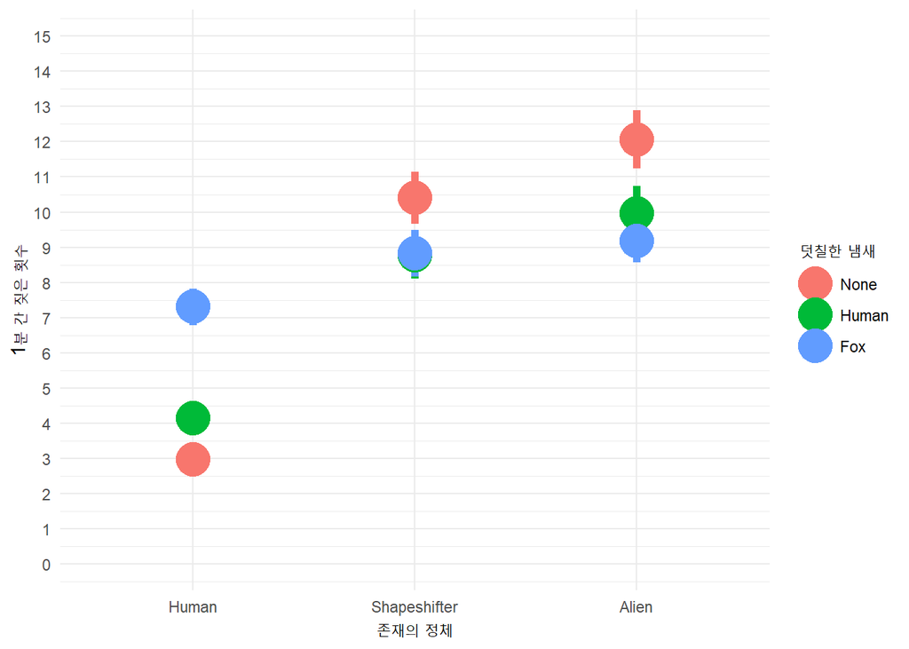

```r
# 집단 간 95퍼센트 신뢰구간 비교하기(신뢰구간이 겹치는지 확인).
scents_tib.1 %>%
  ggplot(aes(x = entity, color = scent_mask, y = vocalisations)) +
  stat_summary(fun.data = "mean_cl_boot", lwd = 2) +
  coord_cartesian(ylim = c(0, 15)) +
  scale_color_discrete("덧칠한 냄새") +
  scale_y_continuous(breaks = seq(0, 15, 1)) +
  xlab("존재의 정체") +
  ylab("1분 간 짖은 횟수") +
  theme_minimal()
```

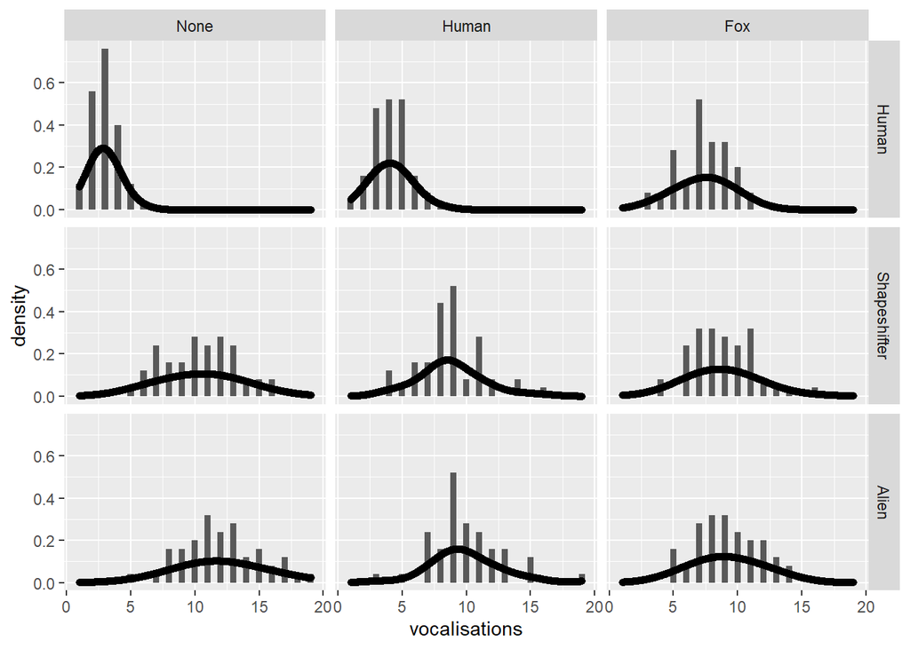

```r
# 히스토그램 그리기.
scents_tib.1 %>%
  ggplot(aes(vocalisations)) +
  geom_histogram(aes(y = ..density..), binwidth = 0.5) +
  geom_density(adjust = 2, lwd = 2) +
  facet_grid(entity ~ scent_mask)
```

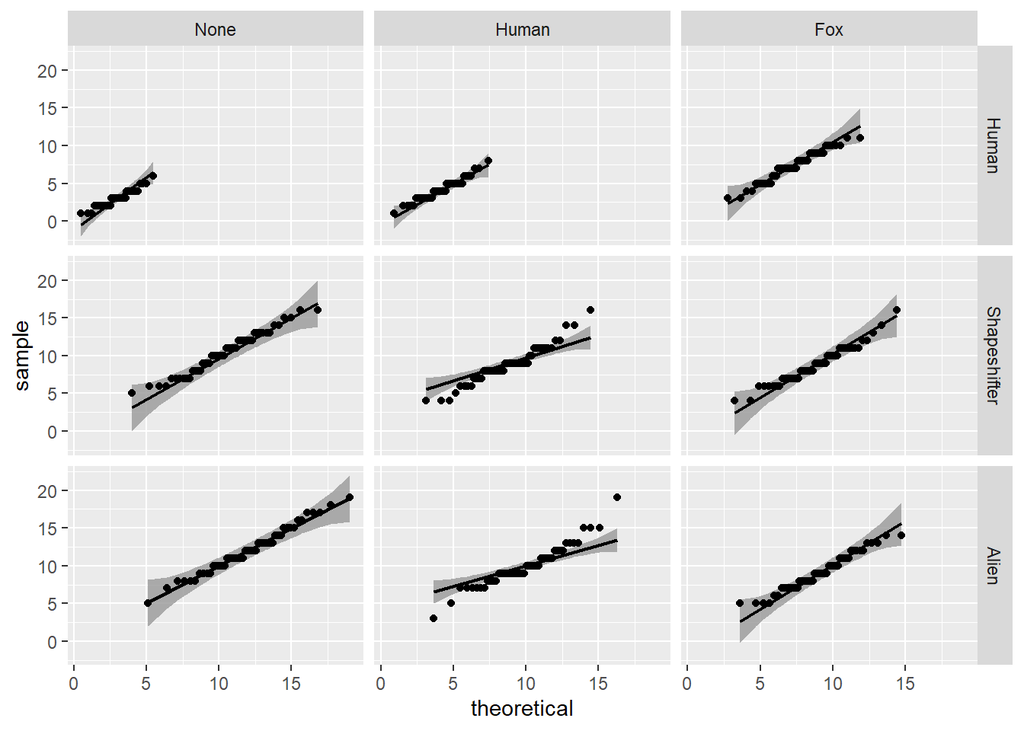

```r
# QQ-플롯 그리기.
library(qqplotr)
scents_tib.1 %>%
  ggplot(aes(sample = vocalisations)) +
  stat_qq_band() +
  stat_qq_line() +
  stat_qq_point() +
  facet_grid(entity ~ scent_mask)
```

- 기술통계량 분석

```r
# 기술통계량 구하기: tidyverse를 이용하는 경우.
scents_tib.1 %>%
  group_by(entity, scent_mask) %>%
  summarise(
    n = n(),
    mean = mean(vocalisations),
    ci_lower = mean_cl_normal(vocalisations)$ymin,
    ci_upper = mean_cl_normal(vocalisations)$ymax)
```

```
## # A tibble: 9 x 6
## # Groups:   entity [3]
##   entity       scent_mask     n  mean ci_lower ci_upper
##   <fct>        <fct>      <int> <dbl>    <dbl>    <dbl>
## 1 Human        None          50  2.98     2.67     3.29
## 2 Human        Human         50  4.16     3.76     4.56
## 3 Human        Fox           50  7.32     6.76     7.88
## 4 Shapeshifter None          50 10.4      9.63    11.2
## 5 Shapeshifter Human         50  8.78     8.08     9.48
## 6 Shapeshifter Fox           50  8.84     8.15     9.53
## 7 Alien        None          50 12.1     11.2     12.9
## 8 Alien        Human         50  9.98     9.20    10.8
## 9 Alien        Fox           50  9.18     8.49     9.87
```

```r
# 기술통계량 구하기: psych를 이용하는 경우.
describeBy(scents_tib.1$vocalisations, list(scents_tib.1$entity, scents_tib.1$scent_mask))
```

```
##
##  Descriptive statistics by group
## : Human
## : None
##    vars  n mean   sd median trimmed  mad min max range skew kurtosis   se
## X1    1 50 2.98 1.08      3    2.92 1.48   1   6     5 0.42        0 0.15
## ------------------------------------------------------------
## : Shapeshifter
## : None
##    vars  n  mean   sd median trimmed  mad min max range skew kurtosis   se
## X1    1 50 10.42 2.79   10.5   10.38 3.71   5  16    11 0.03    -0.86 0.39
## ------------------------------------------------------------
## : Alien
## : None
##    vars  n  mean   sd median trimmed  mad min max range skew kurtosis   se
## X1    1 50 12.06 3.03     12   11.97 2.97   5  19    14 0.17    -0.41 0.43
## ------------------------------------------------------------
## : Human
## : Human
##    vars  n mean   sd median trimmed  mad min max range skew kurtosis  se
## X1    1 50 4.16 1.42      4    4.12 1.48   1   8     7 0.31        0 0.2
## ------------------------------------------------------------
## : Shapeshifter
## : Human
##    vars  n mean   sd median trimmed  mad min max range skew kurtosis   se
## X1    1 50 8.78 2.47      9     8.7 1.48   4  16    12 0.42     0.58 0.35
## ------------------------------------------------------------
## : Alien
## : Human
##    vars  n mean   sd median trimmed  mad min max range skew kurtosis   se
## X1    1 50 9.98 2.75    9.5    9.82 2.22   3  19    16 0.57     1.35 0.39
## ------------------------------------------------------------
## : Human
## : Fox
##    vars  n mean   sd median trimmed  mad min max range  skew kurtosis   se
## X1    1 50 7.32 1.98      7    7.38 2.97   3  11     8 -0.24    -0.62 0.28
## ------------------------------------------------------------
## : Shapeshifter
## : Fox
##    vars  n mean   sd median trimmed  mad min max range skew kurtosis   se
## X1    1 50 8.84 2.43      9    8.72 2.97   4  16    12 0.43     0.23 0.34
## ------------------------------------------------------------
## : Alien
## : Fox
##    vars  n mean   sd median trimmed  mad min max range skew kurtosis   se
## X1    1 50 9.18 2.41      9    9.15 2.97   5  14     9 0.13    -0.82 0.34
```

#### 3) 모형 적합도 분석하기

##### 가. 반복측정 모형 적합도 분석하기

- **afex** 패키지의 `aov_4` 함수 사용
  - (반복측정 예측변수|참여자_변수) 논항: 데이터의 구조에 대한 정보. 개별 참여자(외계인 감별 훈련을 받은 개)가 세 가지 존재의 정체와 masking 냄새에 대해 반복적으로 평정(냄새 맡고 짖기)을 시행했음을 가리킴.
  - 변수: 예측변수 효과 검증.

> aov_4(종속변수 ~ 독립변수들 + (반복측정 예측변수들|참여자_변수), data = 데이터프레임)

```r
library(afex)
scents_afex <- aov_4(vocalisations ~ entity*scent_mask + (entity*scent_mask|dog_id), data = scents_tib.1)
```

- 결과해석
  - 구형성 가정: 예측변수의 층위가 3개 이상일 경우, 2개의 층위 조합 간 관찰값 차이의 분산이 동일해야 함. 구형성 가정 위반으로 Greenhouse-Geisser(약자 `GG`) 교정을 사용했음.
  - `entity` 변수의 효과
    - *F* 검정 결과: *F*(1.98, 96.88) = 315.95, *p* $<$ .001. 짖은 횟수는 masking 냄새의 유형을 무시한다면 존재의 정체에 따라 통계적으로 유의미한 차이가 있음. -효과 크기: 일반화 부분 eta 제곱(`ges`). $η^2_G = .522$은 예측변수 `entity`가 종속변수 `vocalisations`분산의 52.2%를 설명해줌을 의미함.
  - `scent_mask` 변수의 효과
    - *F* 검정 결과: *F*(1.95, 95.75) = 12.91, *p* $<$ .001. 짖은 횟수는 `entity`의 유형을 무시한다면 masking 냄새의 유형에 따라 통계적으로 유의미한 차이가 있음. -효과 크기: 일반화 부분 eta 제곱(`ges`). $η^2_G = .027$은 예측변수 `entity`가 종속변수 `vocalisations`분산의 2.7%를 설명해줌을 의미함.

##### 나. **afex** 패키지를 통해 플롯 그리기

- **afex** 패키지를 통해 플롯 그리기
  - afex_plot 함수: `afex` 객체 생성 후, 이를 바탕으로 상호작용 효과에 대한 플롯을 그릴 수 있음. *y*축에는 자동으로 종속변수가 포함됨.
  - afex 객체: `aov_4`를 통해 생성된 모형.
  - *x*축 변수: *x*축에 놓고자 하는 변수.
  - 라인/모양 변수: 서로 다른 라인/모양을 통해 나타내고자 하는 변수.
  - 패널 변수: 제3의 독립변수(명목척도)가 있을 경우, 해당 변수의 층위들이 서로 다른 패널에 표시됨. `facet_wrap`과 유사한 기능.
  - error: 실험설계가 반복측정(집단 내 설계)이라는 사실을 반영함.
  - **ggplot2**의 문법을 따르므로 플롯은 `ggplot` 객체의 형식으로 표현됨. **ggplot2** 코드를 레이어로 추가할 수도 있음.

> afex_plot(afex 모형 객체, x = x축 변수, trace = 라인/모양 변수, panel = 패널 변수, error = “within”)

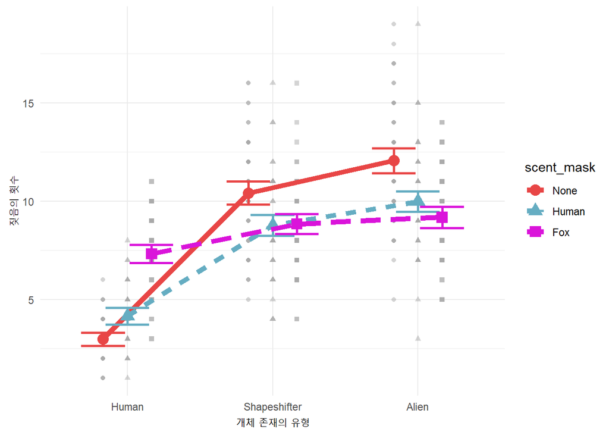

```r
# afex_plot 함수로 변수 간 상호작용 시각화.
afex_plot(scents_afex, "entity", "scent_mask", error = "within",
          line_arg = list(lwd = 2), # line 스타일 관련 논항 정의.
          point_arg = list(size = 4), # point 관련 논항 정의.
          error_arg = list(size = 1), # error bar 관련 논항 정의.
          mapping = c("shape", "color") # trace와 x 관련 미학적 맵핑 논항 정의.
) +
  aes(color = scent_mask, linetype = scent_mask) + # 선 유형 관련 미학적 맵핑 추가.
  scale_color_manual(values = c("#E84646", "#65ADC2", "#DA14DA")) + # 색상의 번호를 직접 사용자 정의.
  labs(x = "개체 존재의 유형", y = "짖음의 횟수") +
  theme_minimal() # 미니멀한 배경으로 바꾸기.
```

##### 다. **emmeans** 패키지의 `emmeans` 함수를 사용한 평균 계산

- estimated marginal means 분석
  - `entity`의 효과
    - 만약 `entity`의 효과가 통계적으로 유의미했다면, 과연 어떤 조건 간 차이로 인해 그런 결과가 발생했는지 알고 싶을 것.
    - **emmeans** 패키지의 `emmeans` 함수: 예측변수 `entity` 조건별 평균을 얻고, 이들 평균을 비교한 사후검정을 실시하는 데 사용. 그렇게 얻은 estimated marginal means는 대조분석 또는 사후검정에 사용 가능.
    - `model` 논항: `model` = “multivariate”은 **구형성을 가정하지 않는** 검정 통계량을 사용하여 대조분석이 실시됨을 의미.
    - 결과해석: 파충류 외계인이나 인간 형상의 외계인의 냄새를 맡을 때 가장 많이 짖었음을 알 수 있음. 이렇게 얻은 평균 `entity_emm`은 대조분석에 투입 가능.
  - `scent_mask`의 효과
    - 만약 `entity`의 효과가 통계적으로 유의미했다면, 과연 어떤 조건 간 차이로 인해 그런 결과가 발생했는지 알고 싶을 것.
    - 결과해석: 아무 냄새를 묻히지 않았을 때, 인간 냄새를 묻혔을 때, 여우 냄새를 묻혔을 때 중 아무 냄새도 안 묻혔을 때와 여우 냄새를 묻혔을 때 가장 많이 짖었음을 알 수 있음. 이렇게 얻은 평균 `scent_mask_emm`은 대조분석에 투입 가능.
  - `entity*scent_mask` 상호작용의 효과
    - 결과해석 1: masking 냄새의 유형이 짖음 횟수에 영향을 미치는 정도는 존재 정체의 유형에 따라 달라짐.
    - 결과해석 2: 존재 정체의 유형이 짖음 횟수에 영향을 미치는 정도는 masking 냄새의 유형에 따라 달라짐.

```r
# entity 변수의 층위별 평균 계산.
entity_emm <- emmeans(scents_afex, ~ entity, model = "multivariate")
entity_emm
```

```
##  entity       emmean    SE df lower.CL upper.CL
##  Human          4.82 0.165 49     4.49     5.15
##  Shapeshifter   9.35 0.291 49     8.76     9.93
##  Alien         10.41 0.316 49     9.77    11.04
##
## Results are averaged over the levels of: scent_mask
## Confidence level used: 0.95
```

```r
# scent_mask 변수의 층위별 평균 계산.
scent_mask_emm <- emmeans(scents_afex, ~ scent_mask, model = "multivariate")
scent_mask_emm
```

```
##  scent_mask emmean    SE df lower.CL upper.CL
##  None         8.49 0.264 49     7.96     9.02
##  Human        7.64 0.249 49     7.14     8.14
##  Fox          8.45 0.245 49     7.95     8.94
##
## Results are averaged over the levels of: entity
## Confidence level used: 0.95
```

```r
# entity*scent_mask 상호작용 변수의 층위별 평균 계산.
scents_emm <- emmeans(scents_afex, c("entity", "scent_mask"), model = "multivariate")
scents_emm
```

```
##  entity       scent_mask emmean    SE df lower.CL upper.CL
##  Human        None         2.98 0.153 49     2.67     3.29
##  Shapeshifter None        10.42 0.394 49     9.63    11.21
##  Alien        None        12.06 0.428 49    11.20    12.92
##  Human        Human        4.16 0.201 49     3.76     4.56
##  Shapeshifter Human        8.78 0.349 49     8.08     9.48
##  Alien        Human        9.98 0.389 49     9.20    10.76
##  Human        Fox          7.32 0.281 49     6.76     7.88
##  Shapeshifter Fox          8.84 0.343 49     8.15     9.53
##  Alien        Fox          9.18 0.341 49     8.49     9.87
##
## Confidence level used: 0.95
```

##### 라. 단순효과 분석하기

- 단순효과 분석
  - 정의: 다른 독립변수의 각 층위별 독립변수의 효과를 분석하는 것.
  - 예시: `entity` 변수의 각 층위별로 `scent_mask` 변수의 효과를 분석. $\rightarrow$ 각 `entity` 집단 내에서 `scent_mask` 변수의 효과는 어떠한가?
  - 논리
    1. 인간 개체에 대해 세 가지 masking 냄새를 묻혔을 때 masking 냄새 평균 계산 및 비교.
    2. 인간 형상의 외계인 개체에 대해 세 가지 masking 냄새를 묻혔을 때 masking 냄새 평균 계산 및 비교.
    3. 파충류 외계인 개체에 대해 세 가지 masking 냄새를 묻혔을 때 masking 냄새 평균 계산 및 비교.
- `emmeans` 패키지의 `joint_tests` 함수 사용: 모형(goggles_afex을 투입하고, 층위별 분석용 독립변수 명시.

```r
# 단순효과 분석: afex 모형 투입, entity 변수 층위별 scent_mask 효과 분석.
joint_tests(scents_afex, "entity")
```

```
## entity = Human:
##  model term df1 df2 F.ratio p.value
##  scent_mask   2  49 166.937  <.0001
##
## entity = Shapeshifter:
##  model term df1 df2 F.ratio p.value
##  scent_mask   2  49  10.984  0.0001
##
## entity = Alien:
##  model term df1 df2 F.ratio p.value
##  scent_mask   2  49  24.969  <.0001
```

```r
# 단순효과 분석: afex 모형 투입, scent_mask 변수 층위별 entity 효과 분석.
joint_tests(scents_afex, "scent_mask")
```

```
## scent_mask = None:
##  model term df1 df2 F.ratio p.value
##  entity       2  49 391.102  <.0001
##
## scent_mask = Human:
##  model term df1 df2 F.ratio p.value
##  entity       2  49 133.309  <.0001
##
## scent_mask = Fox:
##  model term df1 df2 F.ratio p.value
##  entity       2  49  19.099  <.0001
```

##### 마. 사후검정하기

- `entity`와 `scent_mask` 모두 층위가 세 개이므로, 단순효과 분석만으로는 모든 층위 간 비교가 불가능함.
- 사후검정 방법 및 결과해석
  - 함수: `emmeans` 패키지의 `emmeans` 함수 또는 `pairs` 함수를 사용 가능.
  - 결과해석
    - `pairs` 함수에 `scents_emm` 평균을 투입하면 총 36개의 비교결과가 제시. 모든 평균 조합이 검증되기 때문!
    - `entity` 층위별 `scent_mask` 층위 간 비교만 원할 경우, `scent_mask|entity` 논항을 투입하여 평균을 구해야 함.

```r
# emmeans 패키지의 emmeans 함수로 사후검정 시행하기.
emmeans(scents_afex, list(pairwise ~ scent_mask|entity), adjust = "holm")
```

```
## $`emmeans of scent_mask | entity`
## entity = Human:
##  scent_mask emmean    SE df lower.CL upper.CL
##  None         2.98 0.153 49     2.67     3.29
##  Human        4.16 0.201 49     3.76     4.56
##  Fox          7.32 0.281 49     6.76     7.88
##
## entity = Shapeshifter:
##  scent_mask emmean    SE df lower.CL upper.CL
##  None        10.42 0.394 49     9.63    11.21
##  Human        8.78 0.349 49     8.08     9.48
##  Fox          8.84 0.343 49     8.15     9.53
##
## entity = Alien:
##  scent_mask emmean    SE df lower.CL upper.CL
##  None        12.06 0.428 49    11.20    12.92
##  Human        9.98 0.389 49     9.20    10.76
##  Fox          9.18 0.341 49     8.49     9.87
##
## Confidence level used: 0.95
##
## $`pairwise differences of scent_mask | entity`
## entity = Human:
##  2            estimate    SE df t.ratio p.value
##  None - Human    -1.18 0.197 49  -5.980  <.0001
##  None - Fox      -4.34 0.242 49 -17.950  <.0001
##  Human - Fox     -3.16 0.289 49 -10.932  <.0001
##
## entity = Shapeshifter:
##  2            estimate    SE df t.ratio p.value
##  None - Human     1.64 0.383 49   4.281  0.0003
##  None - Fox       1.58 0.391 49   4.043  0.0004
##  Human - Fox     -0.06 0.354 49  -0.170  0.8661
##
## entity = Alien:
##  2            estimate    SE df t.ratio p.value
##  None - Human     2.08 0.378 49   5.506  <.0001
##  None - Fox       2.88 0.422 49   6.833  <.0001
##  Human - Fox      0.80 0.363 49   2.207  0.0321
##
## P value adjustment: holm method for 3 tests
```

```r
# R 내장함수인 pairs 함수로 사후검정시행하기: int_emm 투입 시.
int_emm <- emmeans(scents_afex, ~scent_mask|entity, method = "multivariate")
pairs(int_emm, adjust = "holm") # 위와 동일한 결과 도출.
```

```
## entity = Human:
##  contrast     estimate    SE df t.ratio p.value
##  None - Human    -1.18 0.197 49  -5.980  <.0001
##  None - Fox      -4.34 0.242 49 -17.950  <.0001
##  Human - Fox     -3.16 0.289 49 -10.932  <.0001
##
## entity = Shapeshifter:
##  contrast     estimate    SE df t.ratio p.value
##  None - Human     1.64 0.383 49   4.281  0.0003
##  None - Fox       1.58 0.391 49   4.043  0.0004
##  Human - Fox     -0.06 0.354 49  -0.170  0.8661
##
## entity = Alien:
##  contrast     estimate    SE df t.ratio p.value
##  None - Human     2.08 0.378 49   5.506  <.0001
##  None - Fox       2.88 0.422 49   6.833  <.0001
##  Human - Fox      0.80 0.363 49   2.207  0.0321
##
## P value adjustment: holm method for 3 tests
```

```r
# R 내장함수인 pairs 함수로 사후검정시행하기: scents_emm 투입 시시.
pairs(scents_emm, adjust = "holm") # 위와 결과 비교해보기.
```

```
##  contrast                               estimate    SE df t.ratio p.value
##  Human None - Shapeshifter None            -7.44 0.350 49 -21.250  <.0001
##  Human None - Alien None                   -9.08 0.382 49 -23.764  <.0001
##  Human None - Human Human                  -1.18 0.197 49  -5.980  <.0001
##  Human None - Shapeshifter Human           -5.80 0.293 49 -19.811  <.0001
##  Human None - Alien Human                  -7.00 0.333 49 -21.009  <.0001
##  Human None - Human Fox                    -4.34 0.242 49 -17.950  <.0001
##  Human None - Shapeshifter Fox             -5.86 0.308 49 -19.042  <.0001
##  Human None - Alien Fox                    -6.20 0.302 49 -20.505  <.0001
##  Shapeshifter None - Alien None            -1.64 0.433 49  -3.787  0.0038
##  Shapeshifter None - Human Human            6.26 0.382 49  16.385  <.0001
##  Shapeshifter None - Shapeshifter Human     1.64 0.383 49   4.281  0.0011
##  Shapeshifter None - Alien Human            0.44 0.365 49   1.206  0.9350
##  Shapeshifter None - Human Fox              3.10 0.355 49   8.736  <.0001
##  Shapeshifter None - Shapeshifter Fox       1.58 0.391 49   4.043  0.0020
##  Shapeshifter None - Alien Fox              1.24 0.437 49   2.840  0.0393
##  Alien None - Human Human                   7.90 0.380 49  20.768  <.0001
##  Alien None - Shapeshifter Human            3.28 0.444 49   7.394  <.0001
##  Alien None - Alien Human                   2.08 0.378 49   5.506  <.0001
##  Alien None - Human Fox                     4.74 0.409 49  11.592  <.0001
##  Alien None - Shapeshifter Fox              3.22 0.403 49   7.983  <.0001
##  Alien None - Alien Fox                     2.88 0.422 49   6.833  <.0001
##  Human Human - Shapeshifter Human          -4.62 0.354 49 -13.035  <.0001
##  Human Human - Alien Human                 -5.82 0.377 49 -15.456  <.0001
##  Human Human - Human Fox                   -3.16 0.289 49 -10.932  <.0001
##  Human Human - Shapeshifter Fox            -4.68 0.296 49 -15.803  <.0001
##  Human Human - Alien Fox                   -5.02 0.336 49 -14.930  <.0001
##  Shapeshifter Human - Alien Human          -1.20 0.343 49  -3.500  0.0080
##  Shapeshifter Human - Human Fox             1.46 0.351 49   4.156  0.0016
##  Shapeshifter Human - Shapeshifter Fox     -0.06 0.354 49  -0.170  0.9350
##  Shapeshifter Human - Alien Fox            -0.40 0.383 49  -1.043  0.9350
##  Alien Human - Human Fox                    2.66 0.365 49   7.279  <.0001
##  Alien Human - Shapeshifter Fox             1.14 0.352 49   3.236  0.0152
##  Alien Human - Alien Fox                    0.80 0.363 49   2.207  0.1603
##  Human Fox - Shapeshifter Fox              -1.52 0.378 49  -4.019  0.0020
##  Human Fox - Alien Fox                     -1.86 0.318 49  -5.846  <.0001
##  Shapeshifter Fox - Alien Fox              -0.34 0.394 49  -0.862  0.9350
##
## P value adjustment: holm method for 36 tests
```

## (7) 혼합설계(mixed designs)

- 데이터셋 개관(`date_tib`)
  - 외모, 성격(카리스마), 데이트 전략 간의 상호작용이 스피드 데이트(speed date) 상대의 매력에 대한 평가에 미치는 영향을 알아보는 실험으로부터 수집한 자료.
  - 한 명의 참여자가 총 9명의 데이트 상대자를 만나서 매력평점을 매기게 됨.
  - 독립변수
    - `strategy`(집단 간 변수): 평범한 상호작용 vs. 신비주의 전략.
    - `looks`(집단 내 변수): 상 vs. 중 vs. 하.
    - `personality`(집단 내 변수): 상 vs. 중 vs. 하.
  - 종속변수(`date`): 참여자가 데이트 상대자에 대해 얼마나 많이 매력을 느꼈는지에 대한 평점(0-100점 척도).
- 연구가설: 외모, 성격, 데이트 전략 간의 상호작용이 스피드 데이트 상대의 매력에 대한 평가에 영향을 미칠 것이다.

### A. 모형 적합도 분석하기

- 모형 적합도 분석
  - `afex` 패키지의 `aov_4` 함수 사용.
  - 투입 예측변수: 세 개의 예측 변수, 2원 상호작용 변수(strategy × looks, strategy × personality, looks × personality), 3원 상호작용 변수(strategy × looks × personality).
  - (looks*personality|id): 모든 참여자(`id`)가 `looks` 평정, `personality` 평정, 두 변수의 상호작용에 모두 관여함(반복측정 변수)을 의미.
- 모형 적합도 결과 해석
  - 변수별 주효과
    - `strategy`의 주효과: 다른 모든 변수를 배제한다면, 데이트 상대자가 어떤 데이트 전략을 선택했든 매력평점은 동일할 것이다.
    - `looks`의 주효과: 다른 모든 변수를 배제한다면, 데이트 상대자의 외모에 따라 매력평점이 달라질 것이다.
    - `personality`의 주효과: 다른 모든 변수를 배제한다면, 데이트 상대자의 성격(카리스마)에 따라 매력평점이 달라질 것이다.
  - 상호작용 효과
    - `strategy*looks`
      - 검정결과: *F*(1.92, 34.62) = 80.43, *p* $<$ 0.001.
      - 해석: 참여자의 데이트 전략과 외모 간에 유의미한 상호작용 존재. 즉 참여자의 외모가 매력평점에 미치는 영향은 데이트 전략을 신비주의로 선택하느냐 여부에 따라 달라짐.
    - `strategy*personality`
      - 검정결과: *F*(1.92, 34.62) = 80.43, *p* $<$ 0.001.
      - 해석: 참여자의 데이트 전략과 성격 간에 유의미한 상호작용 존재. 즉 참여자의 성격이 매력평점에 미치는 영향은 데이트 전략을 신비주의로 선택하느냐 여부에 따라 달라짐.
    - `looks*personality`
      - 검정결과: *F*(3.20, 57.55) = 36.63, *p* $<$ 0.001.
      - 해석: 참여자의 외모와 성격 간에 유의미한 상호작용 존재. 즉 참여자의 성격이 매력 평점에 미치는 영향은 외모가 상, 중, 하인지 여부에 따라 달라짐.
    - `strategy*looks*personality`
      - 검정결과: F*(3.20, 57.55) = 24.12,* p* $<$ 0.001.
      - 해석: looks × personality 간 상호작용 효과는 참여자가 데이트 전략을 신비주의로 선택하느냐 여부에 따라 달라짐.

```r
# 문자변수를 요인변수로 변환하기.
load("date_tib.rda")
date_tib.1 <- date_tib %>%
  mutate(
    strategy = as_factor(strategy) %>% fct_relevel("Normal", "Hard to get"),
    looks = as_factor(looks) %>% fct_relevel("Low", "Average", "High"),
    personality = as_factor(personality) %>% fct_relevel("Low", "Average", "High"),
  )

# afex 패키지를 사용하여 모형 적합도 분석하기.
date_afex <- aov_4(date ~ strategy*looks*personality + (looks*personality|id), data = date_tib.1)
```

```
## Contrasts set to contr.sum for the following variables: strategy
```

### B. 데이터 탐색하기

- **afex** 패키지를 통해 플롯 그리기
  - afex 객체: `aov_4`를 통해 생성된 모형.
  - *x*축 변수: *x*축에 놓고자 하는 변수.
  - 라인/모양 변수: 서로 다른 라인/모양을 통해 나타내고자 하는 변수.
  - 패널 변수: 제3의 독립변수(명목척도)가 있을 경우, 해당 변수의 층위들이 서로 다른 패널에 표시됨. `facet_wrap`과 유사한 기능.
  - error: 실험설계가 반복측정(집단 내 설계)이라는 사실을 반영함.
  - **ggplot2**의 문법을 따르므로 플롯은 `ggplot` 객체의 형식으로 표현됨. **ggplot2** 코드를 레이어로 추가할 수도 있음.

> afex_plot(afex 모형 객체, x = x축 변수, trace = 라인/모양 변수, panel = 패널 변수, error = “within”)

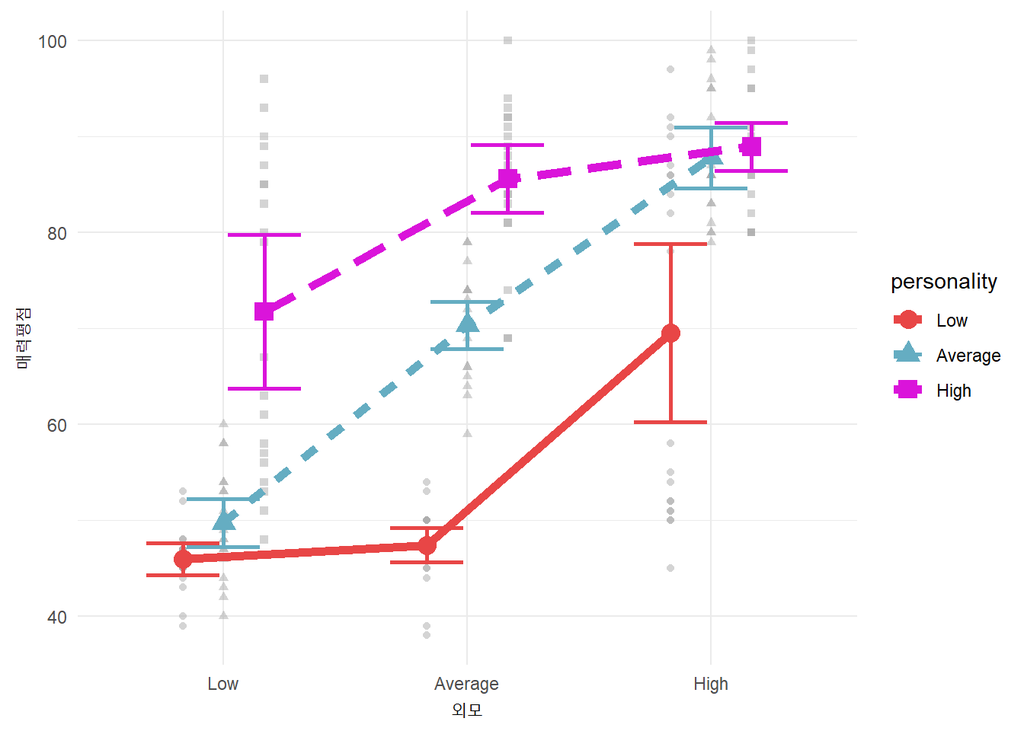

```r
# afex_plot 함수로 2원 상호작용 시각화.
afex_plot(date_afex, "looks", "personality", error = "within",
          line_arg = list(lwd = 2), # line 스타일 관련 논항 정의.
          point_arg = list(size = 4), # point 관련 논항 정의.
          error_arg = list(size = 1), # error bar 관련 논항 정의.
          mapping = c("shape", "color") # trace와 x 관련 미학적 맵핑 논항 정의.
) +
  aes(color = personality, linetype = personality) + # 선 유형 관련 미학적 맵핑 추가.
  scale_color_manual(values = c("#E84646", "#65ADC2", "#DA14DA")) + # 색상의 번호를 직접 사용자 정의.
  labs(x = "외모", y = "매력평점") +
  theme_minimal() # 미니멀한 배경으로 바꾸기.
```

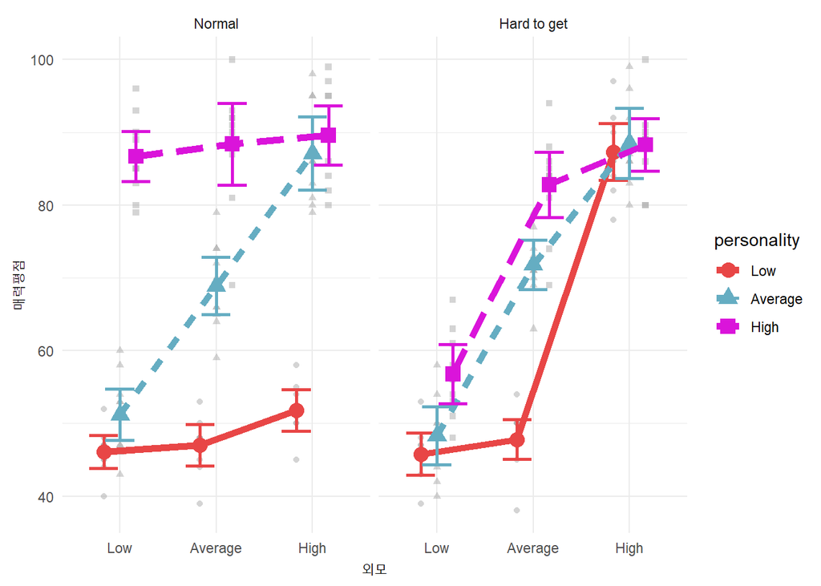

```r
# afex_plot 함수로 3원 상호작용 시각화.
afex_plot(date_afex, "looks", "personality", "strategy", error = "within",
          line_arg = list(lwd = 2), # line 스타일 관련 논항 정의.
          point_arg = list(size = 4), # point 관련 논항 정의.
          error_arg = list(size = 1), # error bar 관련 논항 정의.
          mapping = c("shape", "color") # trace와 x 관련 미학적 맵핑 논항 정의.
) +
  aes(color = personality, linetype = personality) + # 선 유형 관련 미학적 맵핑 추가.
  scale_color_manual(values = c("#E84646", "#65ADC2", "#DA14DA")) + # 색상의 번호를 직접 사용자 정의.
  labs(x = "외모", y = "매력평점") +
  theme_minimal() # 미니멀한 배경으로 바꾸기.
```

### C. 독립적 대조 설정하기

#### 1) 변수별 대조분석

- 모형 적합도를 분석하기 전에 어떤 대조를 설정할 것인지 결정하기
  - `emmeans`의 `contrast` 함수를 사용한 독립적 대조 설정.
  - `looks` 변수: high, average, low로 구성. 극단값인 high와 low를 기준값(norm)인 average와 비교하는 것이 합리적.
  - `personality` 변수: high, average, low로 구성. 극단값인 high와 low를 기준값(norm)인 average와 비교하는 것이 합리적.
- 논항해설
  - `eff`: 변수의 각 층위를 모든 층위의 평균과 비교할 경우.
  - `pairwise`: 변수의 각 층위를 각 층위와 차례로 비교할 경우.
  - `poly`: 다향대조(polynomial contrast). 층위별 트렌드를 2차(혹은 그 이상) 함수로 표현할 수 있는지 여부에 대한 테스트.
  - `trt.vs.ctrl`
    - 각 층위를 준거층위(디폴트는 첫 번째 층위)와 비교하는 경우.
    - ref = x: `x`가 준거층위가 됨. ref = 2는 각 층위를 두 번쨰 층위와 비교하겠다는 것. 여기서 ref = 2로 설정 시 `average`를 준거층위로 두겠다는 의미가 됨.
  - consec: 각 층위(첫 번째 층위)를 이전 층위와 비교할 경우.

> contrast(emmeans 평균 객체, method = “trt.vs.ctrl”, ref = 2, adjust = “holm”)

##### 가. `looks` 변수

- `looks`의 대조분석 결과해석
  - 외모 `high`는 외모 `average`보다 데이트 상대자로부터 통계적으로 유의미하게 더 높은 매력평점을 받음.
  - 외모 `low`는 외모 `average`보다 데이트 상대자로부터 통계적으로 유의미하게 더 낮은 매력평점을 받음.

```r
# emmeans 평균 객체 구하기.
looks_emm <- emmeans(date_afex, ~looks, model = "multivariate")
looks_emm
```

```
##  looks   emmean    SE df lower.CL upper.CL
##  Low       55.8 0.651 18     54.4     57.2
##  Average   67.8 0.820 18     66.1     69.5
##  High      82.1 0.652 18     80.7     83.5
##
## Results are averaged over the levels of: strategy, personality
## Confidence level used: 0.95
```

```r
# looks 예측변수의 대조분석
contrast(looks_emm, method = "trt.vs.ctrl", ref = 2, adjust = "holm") # looks의 high와 low 층위를 두 번째 층위인 average와 비교.
```

```
##  contrast       estimate    SE df t.ratio p.value
##  Low - Average     -12.0 0.946 18 -12.652  <.0001
##  High - Average     14.3 0.950 18  15.066  <.0001
##
## Results are averaged over the levels of: strategy, personality
## P value adjustment: holm method for 2 tests
```

##### 나. `personality` 변수

- `personality`의 대조분석 결과해석
  - 성격 `high`는 외모 `average`보다 데이트 상대자로부터 통계적으로 유의미하게 더 높은 매력평점을 받음.
  - 성격 `low`는 외모 `average`보다 데이트 상대자로부터 통계적으로 유의미하게 더 낮은 매력평점을 받음.

```r
# emmeans 평균 객체 구하기.
pers_emm <- emmeans(date_afex, ~personality, model = "multivariate")
pers_emm
```

```
##  personality emmean    SE df lower.CL upper.CL
##  Low           54.3 0.573 18     53.1     55.5
##  Average       69.3 0.732 18     67.8     70.8
##  High          82.1 1.010 18     80.0     84.2
##
## Results are averaged over the levels of: strategy, looks
## Confidence level used: 0.95
```

```r
# looks 예측변수의 대조분석
contrast(pers_emm, method = "trt.vs.ctrl", ref = 2, adjust = "holm") # personality의 high와 low 층위를 두 번째 층위인 average와 비교.
```

```
##  contrast       estimate    SE df t.ratio p.value
##  Low - Average     -15.0 0.994 18 -15.098  <.0001
##  High - Average     12.8 1.221 18  10.485  <.0001
##
## Results are averaged over the levels of: strategy, looks
## P value adjustment: holm method for 2 tests
```

#### 2) 상호작용 대조분석

##### 가. `strategy*looks` 상호작용

- 논항해설
  - `interaction = c(변수1 = "contrast 방법", 변수2 = "contrast 방법" ...)`: 각 변수와 우리가 적용하고자 하는 대조방법을 가리킴.
  - ref = 2: `looks`의 high와 low 층위를 두 번째 층위인 average와 비교
- `strategy*looks`의 대조분석 결과해석
  - 첫 번째 대조: 외모가 중인 상대와 비교했을 때 외모가 하인 상대의 효과를 서로 다른 데이트 전략에 따라 비교.
    - 검정결과: *t*(18) = 5.50, *p* $<$ 0.001.
    - 해석(평균비교를 함께 참조)
      1. 외모가 중인 참여자의 경우 외모가 하인 참여자와 비교 시, 참여자가 평범하게 행동할 때보다 신비주의 전략을 사용했을 때 매력평점이 상승폭이 더 컸음.
      2. 외모가 하인 참여자의 경우 외모가 중인 참여자와 비교 시, 참여자가 평범하게 행동할 때보다 신비주의 전략을 사용했을 때 매력평점이 하락폭이 더 컸음.
  - 두 번째 대조: 외모가 중인 상대와 비교했을 때 외모가 상인 상대의 효과를 서로 다른 데이트 전략에 따라 비교.
    - 검정결과: *t*(18) = -6.58, *p* $<$ 0.001.
    - 해석
      1. 외모가 중인 참여자의 경우 외모가 상인 참여자와 비교 시, 참여자가 평범하게 행동할 때보다 신비주의 전략을 사용했을 때 매력평점이 하락폭이 더 컸음.
      2. 외모가 상인 참여자의 경우 외모가 중인 참여자와 비교 시, 참여자가 평범하게 행동할 때보다 신비주의 전략을 사용했을 때 매력평점 상승폭이 더 컸음.

> contrast(emmeans 평균 객체, interaction = c(변수1 = “contrast 방법”, 변수2 = “contrast 방법” …), ref = x, adjust = “holm”)

```r
# emmeans 평균 객체 구하기.
strat_looks_emm <- emmeans(date_afex, ~strategy*looks, model = "multivariate")
strat_looks_emm
```

```
##  strategy    looks   emmean    SE df lower.CL upper.CL
##  Normal      Low       61.3 0.921 18     59.4     63.3
##  Hard to get Low       50.3 0.921 18     48.4     52.2
##  Normal      Average   68.1 1.159 18     65.7     70.5
##  Hard to get Average   67.5 1.159 18     65.0     69.9
##  Normal      High      76.2 0.923 18     74.2     78.1
##  Hard to get High      88.0 0.923 18     86.1     90.0
##
## Results are averaged over the levels of: personality
## Confidence level used: 0.95
```

```r
# strategy × looks 상호작용의 대조분석
contrast(strat_looks_emm,
         interaction = c(strategy = "trt.vs.ctrl", looks = "trt.vs.ctrl"),
         ref = 2, # looks의 high와 low 층위를 두 번째 층위인 average와 비교.
         adjust = "holm")
```

```
##  strategy_trt.vs.ctrl looks_trt.vs.ctrl estimate   SE df t.ratio p.value
##  Normal - Hard to get Low - Average         10.4 1.89 18   5.498  <.0001
##  Normal - Hard to get High - Average       -12.5 1.90 18  -6.577  <.0001
##
## Results are averaged over the levels of: personality
## P value adjustment: holm method for 2 tests
```

##### 나. `strategy*personality` 상호작용

```r
# emmeans 평균 객체 구하기.
strat_pers_emm <- emmeans(date_afex, ~strategy*personality, model = "multivariate")
strat_pers_emm
```

```
##  strategy    personality emmean   SE df lower.CL upper.CL
##  Normal      Low           48.3 0.81 18     46.6     50.0
##  Hard to get Low           60.3 0.81 18     58.6     62.0
##  Normal      Average       69.1 1.03 18     66.9     71.2
##  Hard to get Average       69.5 1.03 18     67.4     71.7
##  Normal      High          88.2 1.43 18     85.2     91.2
##  Hard to get High          76.0 1.43 18     73.0     79.0
##
## Results are averaged over the levels of: looks
## Confidence level used: 0.95
```

```r
# strategy × personality 상호작용의 대조분석
contrast(strat_pers_emm,
         interaction = c(strategy = "trt.vs.ctrl", personality = "trt.vs.ctrl"),
         ref = 2, # personality의 high와 low 층위를 두 번째 층위인 average와 비교.
         adjust = "holm")
```

```
##  strategy_trt.vs.ctrl personality_trt.vs.ctrl estimate   SE df t.ratio p.value
##  Normal - Hard to get Low - Average              -11.5 1.99 18  -5.804  <.0001
##  Normal - Hard to get High - Average              12.7 2.44 18   5.215  0.0001
##
## Results are averaged over the levels of: looks
## P value adjustment: holm method for 2 tests
```

##### 다. `looks*personality` 상호작용

```r
# emmeans 평균 객체 구하기.
looks_pers_emm  <- emmeans(date_afex, ~looks*personality, model = "multivariate")
looks_pers_emm
```

```
##  looks   personality emmean    SE df lower.CL upper.CL
##  Low     Low           46.0 0.746 18     44.4     47.5
##  Average Low           47.4 0.888 18     45.5     49.3
##  High    Low           69.5 1.019 18     67.4     71.7
##  Low     Average       49.8 1.211 18     47.2     52.3
##  Average Average       70.3 1.172 18     67.9     72.8
##  High    Average       87.8 1.408 18     84.8     90.8
##  Low     High          71.8 1.249 18     69.1     74.4
##  Average High          85.6 1.721 18     82.0     89.2
##  High    High          89.0 1.383 18     86.0     91.9
##
## Results are averaged over the levels of: strategy
## Confidence level used: 0.95
```

```r
# looks × personality 상호작용의 대조분석
contrast(looks_pers_emm,
         interaction = c(looks = "trt.vs.ctrl", personality = "trt.vs.ctrl"),
         ref = 2,
         adjust = "holm")
```

```
##  looks_trt.vs.ctrl personality_trt.vs.ctrl estimate   SE df t.ratio p.value
##  Low - Average     Low - Average              19.15 2.03 18   9.413  <.0001
##  High - Average    Low - Average               4.70 2.32 18   2.023  0.0582
##  Low - Average     High - Average              6.75 2.70 18   2.496  0.0450
##  High - Average    High - Average            -14.10 3.01 18  -4.684  0.0006
##
## Results are averaged over the levels of: strategy
## P value adjustment: holm method for 4 tests
```

##### 라. `strategy*looks*personality` 상호작용

```r
# emmeans 평균 객체 구하기.
three_way_emm <- emmeans(date_afex, c("strategy", "looks", "personality"), model = "multivariate")
three_way_emm
```

```
##  strategy    looks   personality emmean   SE df lower.CL upper.CL
##  Normal      Low     Low           46.1 1.06 18     43.9     48.3
##  Hard to get Low     Low           45.8 1.06 18     43.6     48.0
##  Normal      Average Low           47.0 1.26 18     44.4     49.6
##  Hard to get Average Low           47.8 1.26 18     45.2     50.4
##  Normal      High    Low           51.8 1.44 18     48.8     54.8
##  Hard to get High    Low           87.3 1.44 18     84.3     90.3
##  Normal      Low     Average       51.2 1.71 18     47.6     54.8
##  Hard to get Low     Average       48.3 1.71 18     44.7     51.9
##  Normal      Average Average       68.9 1.66 18     65.4     72.4
##  Hard to get Average Average       71.8 1.66 18     68.3     75.3
##  Normal      High    Average       87.1 1.99 18     82.9     91.3
##  Hard to get High    Average       88.5 1.99 18     84.3     92.7
##  Normal      Low     High          86.7 1.77 18     83.0     90.4
##  Hard to get Low     High          56.8 1.77 18     53.1     60.5
##  Normal      Average High          88.4 2.43 18     83.3     93.5
##  Hard to get Average High          82.8 2.43 18     77.7     87.9
##  Normal      High    High          89.6 1.96 18     85.5     93.7
##  Hard to get High    High          88.3 1.96 18     84.2     92.4
##
## Confidence level used: 0.95
```

```r
# strategy × looks × personality 상호작용의 대조분석
contrast(three_way_emm,
         interaction = c(strategy = "trt.vs.ctrl", looks = "trt.vs.ctrl", personality = "trt.vs.ctrl"),
         ref = 2,
         adjust = "holm")
```

```
##  strategy_trt.vs.ctrl looks_trt.vs.ctrl personality_trt.vs.ctrl estimate   SE
##  Normal - Hard to get Low - Average     Low - Average               -4.7 4.07
##  Normal - Hard to get High - Average    Low - Average              -36.2 4.65
##  Normal - Hard to get Low - Average     High - Average              18.5 5.41
##  Normal - Hard to get High - Average    High - Average              -5.8 6.02
##  df t.ratio p.value
##  18  -1.155  0.5263
##  18  -7.789  <.0001
##  18   3.421  0.0091
##  18  -0.963  0.5263
##
## P value adjustment: holm method for 4 tests
```

# 6. **jamovi** 패키지를 사용한 통계분석

- **jamovi** 패키지의 개요
  - 소개: 무료 오픈소스 GUI 기반 통계분석용 R 소프트웨어.
  - 특징
    - SPSS와 매우 유사한 GUI 지님.
    - 원할 경우 point & click과 R 코딩을 섞어 사용 가능.
    - 기본 내장 프로그램말고도, 다양한 plug-in 모듈(jamovi용 패키지)이 있어서 별도로 jamovi library에서 다운받아 설치 및 사용 가능.
  - 데이터 반입하기
    - 쉼표로 분리된 파일(.csv)
    - 텍스트 파일(.txt)
    - 엑셀 파일(.xlsx)
    - R 데이터 파일(.RDATA, .RDS)
    - SPSS(.sav, .zsav, .por)
    - SAS binary files(.sas7bdat, .xpt)
    - Stata(.dta)
    - JASP(.jasp)
  - 데이터 반출하기
    - jamovi 파일(.omv) 형태로 스프레드 시트, 표, 그림 통합 저장 가능.
    - 그림이나 표만 따로 저장 가능,
- **jamovi** 패키지 실습
  - 기술통계 분석 및 플롯 그리기.
  - 회귀분석.
  - 분산분석.